# Reproducible Research Course Project 1

Andrew Maloney

February 21, 2016

Load the activity.csv data by setting the working directory and reading it into R.

```r
setwd("C:/Users/Maloney/Desktop/Data/Activity")
data <- read.csv("activity.csv")
```

Calculate the total number of steps taken per day.

```r
steps_per_day <- tapply(data$steps, data$date, sum, na.rm=TRUE)
```

Create a histogram of the total number of steps per day. Calculate and report the mean and median of the total number of steps taken per day.

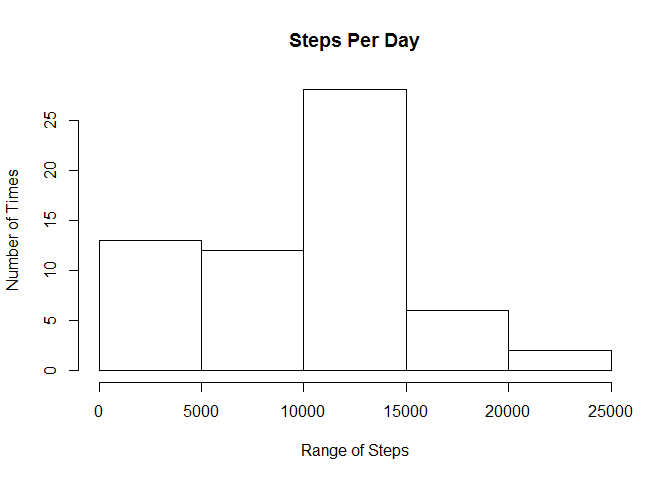

```r
hist(steps_per_day, xlab = "Range of Steps", ylab = "Number of Times", main = "Steps Per Day")
```

```r
mean(steps_per_day)
```

```
## [1] 9354.23
```

```r
median(steps_per_day)
```

```
## [1] 10395
```

The mean number of steps is 9,354.23, and the median is 10,395 steps.

Now, make a time series plot of the 5-minute intervals and average number of steps taken, averaged across all days.

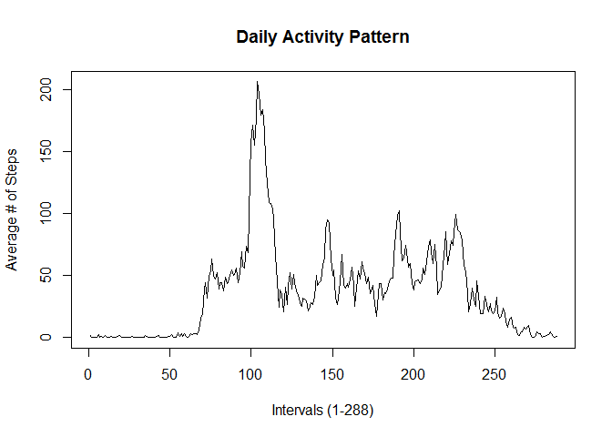

```r
steps_per_interval <- tapply(data$steps, data$interval, mean, na.rm=TRUE)
Activity_Pattern <- data.frame(steps_per_interval)
plot(Activity_Pattern, type="l", xlab="Intervals (1-288)", ylab="Average # of Steps", main = "Daily Activity Pattern")
```

Now, count the number of missing values (NA) in the dataset. The total number of missing values is 2,304.

```r
sum(is.na(data))
```

```
## [1] 2304
```

Create new dataset that’s identical to the original activity data, but replace all the missing “steps” observations with the mean number of steps per interval.

```r
new_data <- data
new_data$steps[which(is.na(new_data$steps))] <- mean(steps_per_interval)
```

Calculate the total number of steps taken per day now that missing values are filled in. Create a histogram of the total number of steps per day. Calculate and report the mean and median of the total number of steps taken per day.

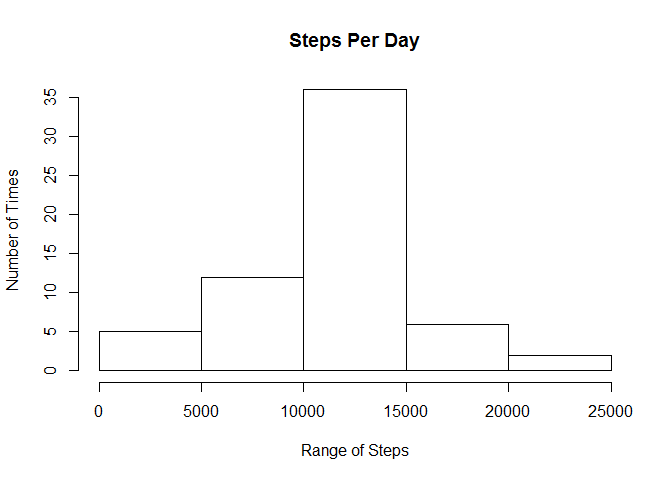

```r
new_steps_per_day <- tapply(new_data$steps, new_data$date, sum, na.rm=TRUE)
hist(new_steps_per_day, xlab = "Range of Steps", ylab = "Number of Times", main = "Steps Per Day")
```

```r
mean(new_steps_per_day)
```

```
## [1] 10766.19
```

```r
median(new_steps_per_day)
```

```
## [1] 10766.19
```

The adjusted mean AND median of the new data are 10,766.2. Filling in the missing values increased both measures and centered the distribution a bit more.

Now, create a new factor variable indicating whether a given day is a weekday or weekend day.

```r
new_data$date <- as.Date(new_data$date)
days <- weekdays(new_data$date)
new_data$weekend <- sapply(days, switch, Monday = 'weekday', Tuesday = 'weekday', Wednesday = 'weekday', Thursday = 'weekday', Friday = 'weekday', Saturday = 'weekend', Sunday = 'weekend')
```

Create a panel plot of the 5-minute interval and the average number of steps taken, averaged across all weekday days or weekend days.

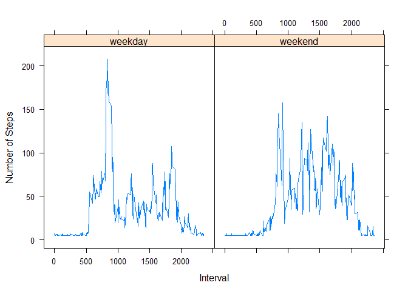

```r
library(lattice)
result <- aggregate(steps ~ weekend + interval, new_data, mean)
xyplot(result$steps ~ result$interval | factor(result$weekend), type="l", xlab="Interval", ylab="Number of Steps")
```